# Analiza Zachowań Zakupowych

Autor: Diana Kalyniak

## **Badanie preferencji klientów w świecie odzieży**

### Przeprowadzam analizę na podstawie danych ze sklepu odzieżowego.Celem mojego projektu jest zrozumienie zachowań klientów, analiza popularności produktów, badanie wpływu różnych czynników na zakupy.

### Analiza zachowań klientów to proces badawczy, który odgrywa kluczową rolę w dzisiejszym świecie biznesu. Dzięki analizie danych z zakresu zachowań klientów, biznesy zdobywają nie tylko wgląd w preferencje, lecz także możliwość przewidywania trendów, doskonalenia oferty produktowej oraz usług, a także budowania lojalności klienta.Istotne jest zrozumienie, dlaczego klienci podejmują określone decyzje zakupow.

### Dlaczego badania są tak ważne?

- Personalizacja Oferty
- Przewidywanie trendów zakupowych
- Budowania relacji z klientami
- Ulepszanie procesów zakupowych

## **Opinia klienta odgrywa ważną rolę**

### Rzetelne zrozumienie opinii klientów na temat produktów może dostarczyć wartościowych wskazówek dla biznesów, pozwalając na ciągłe doskonalenie i dostosowywanie się do potrzeb konsumentów.Wykres skrzynkowy pozwala na spojrzenie na rozkład ocen recenzji w różnych kategoriach.

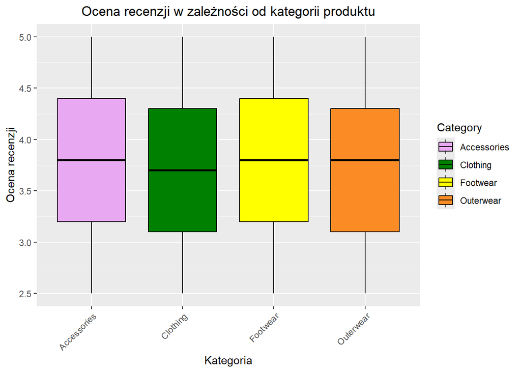

### Średnia ocen w kategoriach akcesoriów, obuwia i odzieży wierzchniej jest taka sama i wynosi 3.8,a w kategorii odzieży jest nieco niższa. Niestety w kategoriach odzieży wierzchniej i odzieży jest więcej negatywnych recenzji niż w pozostałych.To sugeruje , że sklep powinien zwrócić uwagę na kategorie odzieży i odzieży wierzchniej, poprawić ten obszar.

## **Kobiety vs Mężczyźni:na kim się skupić?**

### Ważne jest, aby dokładnie zidentyfikować grupę docelową w kontekście zakupów. Często popełnianym błędem jest założenie, że jedynie kobiety cieszą się zakupami, podczas gdy w rzeczywistości grupa docelowa może obejmować również mężczyzn.

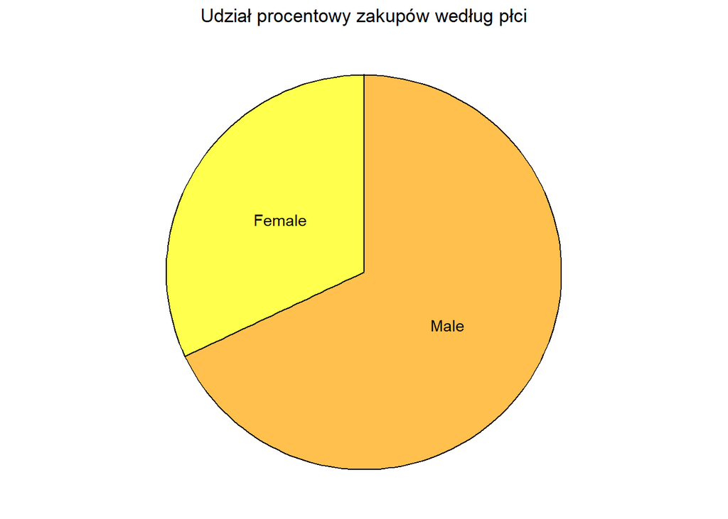

### Analiza danych zakupowych w tym sklepie wskazuje, że mężczyźni również są aktywnymi konsumentami, co stanowi istotny czynnik przy kształtowaniu strategii marketingowych i ofert produktowych.

## **Najpopularniejsze przedmioty**

### Tabela zawiera informacje o najpopularniejszych przedmiotach w danych. Zawiera kolumny z nazwami przedmiotów, ich kategoriami, średnimi kosztami oraz liczbą wystąpień każdego przedmiotu.

|  | Item | Category | Cost | Count |
| --- | --- | --- | --- | --- |
| 1 | Blouse | Clothing | 60.88 | 171 |
| 2 | Jewelry | Accessories | 58.54 | 171 |
| 3 | Pants | Clothing | 59.01 | 171 |
| 4 | Shirt | Clothing | 61.14 | 169 |
| 5 | Dress | Clothing | 62.17 | 166 |
| 6 | Sweater | Clothing | 57.70 | 164 |
| 7 | Jacket | Outerwear | 56.74 | 163 |
| 8 | Belt | Accessories | 59.84 | 161 |
| 9 | Coat | Outerwear | 57.61 | 161 |
| 10 | Sunglasses | Accessories | 59.93 | 161 |

[output cut: 15 more lines]

### Bluzki, biżuteria i spodnie są najpopularniejsze, a największą wartość mają t-shirty.Zwiększenie dostępności i różnorodności tych produktów w magazynie może przynieść zyski. Warto skupić się na oferowanie promocji, rabatów na te towary.

## **Wpływ wieku na zakupy**

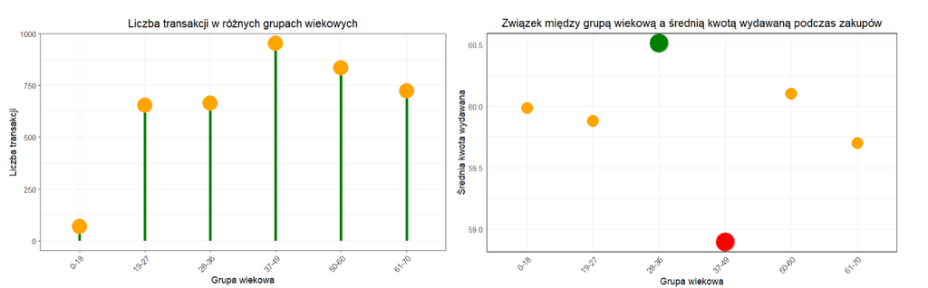

## **Rozkład kwoty wydanej w różnych lokalizacjach**

### Zidentyfikowanie stanów, gdzie wydatki są szczególnie wysokie lub niskie, może mieć kluczowe znaczenie przy podejmowaniu decyzji biznesowych, takich jak lokalizacja nowych sklepów. Pokazano to na *interaktywnym* wykresie:

[interactive chart not shown]

### W takich stanach ludzie najbardziej lubią robić zakupy i wydają na nie najwięcej pieniędzy:*Montana,Idaho,Nevada,Clifornia,Illinois*

## **Popularne rozmiary wśród klientów**

|  | Size | Ilosc |
| --- | --- | --- |
| 1 | L | 1053 |
| 2 | M | 1755 |
| 3 | S | 663 |
| 4 | XL | 429 |

### Analiza wykazała, że najczęściej spotykanym rozmiarem jest **M**, co oznacza, że produkty w tym rozmiarze muszą być produkowane częściej i będą się szybciej sprzedawać.

## **Która kategoria dominuje?**

[interactive chart not shown]

### Na powyższym wykresie “chmura słów” przedstawiono częstość występowania różnych kategorii. Największą kategorią jest **Clothing**, podczas gdy najmniejszą *Outerwear*.Rozmiar czcionki zależy od częstości występowania w danych. Po kliknięciu można zobaczyć częstotliwość występowania kategorii w danych

## **Najpopularniejsze kolory odzieży: Trendy i Wyrażanie Stylu**

### Analiza danych dotyczących preferowanych kolorów w odzieży ujawniła, że wśród najpopularniejszych kolorów dominują:

### Oliwkowy Żółty Srebrny Teal Zielony

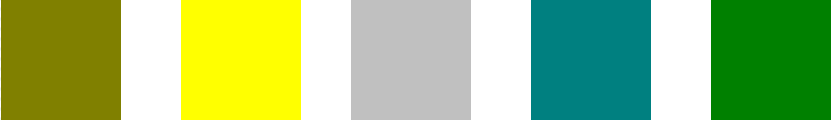

### Pomimo popularnych kolorów roku niebieskiego i różowego, konsumenci często wybierają odzież opartą na kolorach uniwersalnych i praktycznych w codziennym użytkowaniu.Odcienie, które pasują do różnych stylizacji, a jednocześnie są praktyczne w codziennym użytkowaniu, cieszą się większym zainteresowaniem niż kolory trendy.

## **Rozkład ocen w zależności od popularnych kolorów**

### Wykres gęstości ocen w zależności od popularnych kolorów prezentuje, w jaki sposób oceny produktów rozkładają się w kontekście różnych kolorów.

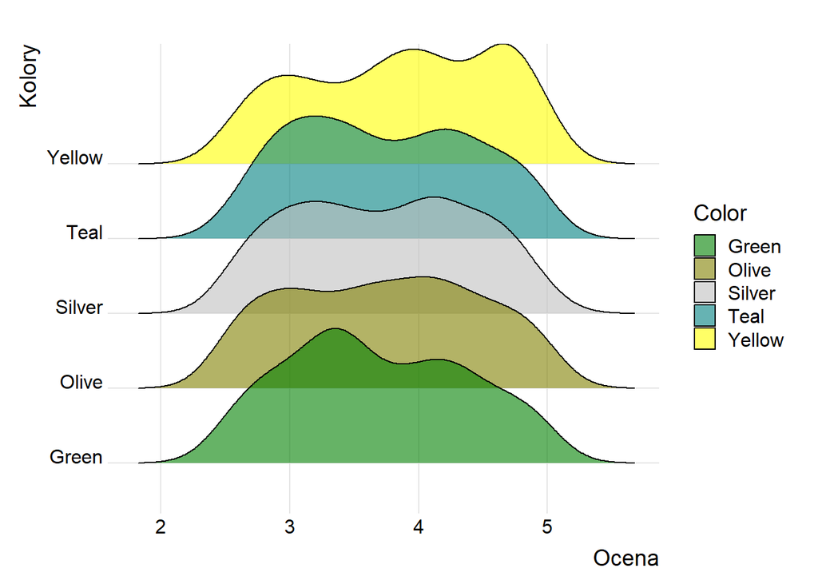

## **Źródła informacji:**

### 1) www.kaggle.com

### 2) [www.colorhunt.co](https://colorhunt.co/)